# Boston Housing Price prediction

Loading required libraries

```r
#library(dplyr)
#library(ggplot2)
#library(GGally)
#library(gridExtra)
#library(scales)
#library(lattice)
#library(reshape2)
#library(caret)
#library(glmnet) #used for regularized regression
#library(MASS)
```

Loading the datasets

```r
train<-read.csv("train (1).csv")
test<-read.csv("test (1).csv")
#Ignoring the column Id from the data
train<-subset(train,select = -c(Id)) #Removing the Id column as it doesn't contribute to the Saleprice
test<-subset(test,select = -c(Id))
```

Overview of training data

```r
# Check Dimension of the data
dim(train)
```

```
[1] 1460   80
```

```r
# Descriptive summary of each variables in the data
summary(train)
```

```
   MSSubClass       MSZoning     LotFrontage        LotArea        Street      Alley      LotShape  LandContour  Utilities      LotConfig
 Min.   : 20.0   C (all):  10   Min.   : 21.00   Min.   :  1300   Grvl:   6   Grvl:  50   IR1:484   Bnk:  63    AllPub:1459   Corner : 263
 1st Qu.: 20.0   FV     :  65   1st Qu.: 59.00   1st Qu.:  7554   Pave:1454   Pave:  41   IR2: 41   HLS:  50    NoSeWa:   1   CulDSac:  94
 Median : 50.0   RH     :  16   Median : 69.00   Median :  9478               NA's:1369   IR3: 10   Low:  36                  FR2    :  47
 Mean   : 56.9   RL     :1151   Mean   : 70.05   Mean   : 10517                           Reg:925   Lvl:1311                  FR3    :   4
 3rd Qu.: 70.0   RM     : 218   3rd Qu.: 80.00   3rd Qu.: 11602                                                               Inside :1052
 Max.   :190.0                  Max.   :313.00   Max.   :215245
                                NA's   :259
 LandSlope   Neighborhood   Condition1     Condition2     BldgType      HouseStyle   OverallQual      OverallCond      YearBuilt     YearRemodAdd
 Gtl:1382   NAmes  :225   Norm   :1260   Norm   :1445   1Fam  :1220   1Story :726   Min.   : 1.000   Min.   :1.000   Min.   :1872   Min.   :1950
 Mod:  65   CollgCr:150   Feedr  :  81   Feedr  :   6   2fmCon:  31   2Story :445   1st Qu.: 5.000   1st Qu.:5.000   1st Qu.:1954   1st Qu.:1967
 Sev:  13   OldTown:113   Artery :  48   Artery :   2   Duplex:  52   1.5Fin :154   Median : 6.000   Median :5.000   Median :1973   Median :1994
            Edwards:100   RRAn   :  26   PosN   :   2   Twnhs :  43   SLvl   : 65   Mean   : 6.099   Mean   :5.575   Mean   :1971   Mean   :1985
            Somerst: 86   PosN   :  19   RRNn   :   2   TwnhsE: 114   SFoyer : 37   3rd Qu.: 7.000   3rd Qu.:6.000   3rd Qu.:2000   3rd Qu.:2004
            Gilbert: 79   RRAe   :  11   PosA   :   1                 1.5Unf : 14   Max.   :10.000   Max.   :9.000   Max.   :2010   Max.   :2010
            (Other):707   (Other):  15   (Other):   2                 (Other): 19
   RoofStyle       RoofMatl     Exterior1st   Exterior2nd    MasVnrType    MasVnrArea     ExterQual ExterCond  Foundation  BsmtQual   BsmtCond
 Flat   :  13   CompShg:1434   VinylSd:515   VinylSd:504   BrkCmn : 15   Min.   :   0.0   Ex: 52    Ex:   3   BrkTil:146   Ex  :121   Fa  :  45
 Gable  :1141   Tar&Grv:  11   HdBoard:222   MetalSd:214   BrkFace:445   1st Qu.:   0.0   Fa: 14    Fa:  28   CBlock:634   Fa  : 35   Gd  :  65
 Gambrel:  11   WdShngl:   6   MetalSd:220   HdBoard:207   None   :864   Median :   0.0   Gd:488    Gd: 146   PConc :647   Gd  :618   Po  :   2
 Hip    : 286   WdShake:   5   Wd Sdng:206   Wd Sdng:197   Stone  :128   Mean   : 103.7   TA:906    Po:   1   Slab  : 24   TA  :649   TA  :1311
 Mansard:   7   ClyTile:   1   Plywood:108   Plywood:142   NA's   :  8   3rd Qu.: 166.0             TA:1282   Stone :  6   NA's: 37   NA's:  37
 Shed   :   2   Membran:   1   CemntBd: 61   CmentBd: 60                 Max.   :1600.0                       Wood  :  3
                (Other):   2   (Other):128   (Other):136                 NA's   :8
 BsmtExposure BsmtFinType1   BsmtFinSF1     BsmtFinType2   BsmtFinSF2        BsmtUnfSF       TotalBsmtSF      Heating     HeatingQC CentralAir
 Av  :221     ALQ :220     Min.   :   0.0   ALQ :  19    Min.   :   0.00   Min.   :   0.0   Min.   :   0.0   Floor:   1   Ex:741    N:  95
 Gd  :134     BLQ :148     1st Qu.:   0.0   BLQ :  33    1st Qu.:   0.00   1st Qu.: 223.0   1st Qu.: 795.8   GasA :1428   Fa: 49    Y:1365
 Mn  :114     GLQ :418     Median : 383.5   GLQ :  14    Median :   0.00   Median : 477.5   Median : 991.5   GasW :  18   Gd:241
 No  :953     LwQ : 74     Mean   : 443.6   LwQ :  46    Mean   :  46.55   Mean   : 567.2   Mean   :1057.4   Grav :   7   Po:  1
 NA's: 38     Rec :133     3rd Qu.: 712.2   Rec :  54    3rd Qu.:   0.00   3rd Qu.: 808.0   3rd Qu.:1298.2   OthW :   2   TA:428
              Unf :430     Max.   :5644.0   Unf :1256    Max.   :1474.00   Max.   :2336.0   Max.   :6110.0   Wall :   4
              NA's: 37                      NA's:  38
 Electrical     X1stFlrSF      X2ndFlrSF     LowQualFinSF       GrLivArea     BsmtFullBath     BsmtHalfBath        FullBath        HalfBath
 FuseA:  94   Min.   : 334   Min.   :   0   Min.   :  0.000   Min.   : 334   Min.   :0.0000   Min.   :0.00000   Min.   :0.000   Min.   :0.0000
 FuseF:  27   1st Qu.: 882   1st Qu.:   0   1st Qu.:  0.000   1st Qu.:1130   1st Qu.:0.0000   1st Qu.:0.00000   1st Qu.:1.000   1st Qu.:0.0000
 FuseP:   3   Median :1087   Median :   0   Median :  0.000   Median :1464   Median :0.0000   Median :0.00000   Median :2.000   Median :0.0000
 Mix  :   1   Mean   :1163   Mean   : 347   Mean   :  5.845   Mean   :1515   Mean   :0.4253   Mean   :0.05753   Mean   :1.565   Mean   :0.3829
 SBrkr:1334   3rd Qu.:1391   3rd Qu.: 728   3rd Qu.:  0.000   3rd Qu.:1777   3rd Qu.:1.0000   3rd Qu.:0.00000   3rd Qu.:2.000   3rd Qu.:1.0000
 NA's :   1   Max.   :4692   Max.   :2065   Max.   :572.000   Max.   :5642   Max.   :3.0000   Max.   :2.00000   Max.   :3.000   Max.   :2.0000

```

[output cut: 16 more lines]

```
  ScreenPorch        PoolArea        PoolQC       Fence      MiscFeature    MiscVal             MoSold           YrSold        SaleType
 Min.   :  0.00   Min.   :  0.000   Ex  :   2   GdPrv:  59   Gar2:   2   Min.   :    0.00   Min.   : 1.000   Min.   :2006   WD     :1267
 1st Qu.:  0.00   1st Qu.:  0.000   Fa  :   2   GdWo :  54   Othr:   2   1st Qu.:    0.00   1st Qu.: 5.000   1st Qu.:2007   New    : 122
 Median :  0.00   Median :  0.000   Gd  :   3   MnPrv: 157   Shed:  49   Median :    0.00   Median : 6.000   Median :2008   COD    :  43
 Mean   : 15.06   Mean   :  2.759   NA's:1453   MnWw :  11   TenC:   1   Mean   :   43.49   Mean   : 6.322   Mean   :2008   ConLD  :   9
 3rd Qu.:  0.00   3rd Qu.:  0.000               NA's :1179   NA's:1406   3rd Qu.:    0.00   3rd Qu.: 8.000   3rd Qu.:2009   ConLI  :   5
 Max.   :480.00   Max.   :738.000                                        Max.   :15500.00   Max.   :12.000   Max.   :2010   ConLw  :   5
                                                                                                                            (Other):   9
 SaleCondition    SalePrice
 Abnorml: 101   Min.   : 34900
 AdjLand:   4   1st Qu.:129975
 Alloca :  12   Median :163000
 Family :  20   Mean   :180921
 Normal :1198   3rd Qu.:214000
 Partial: 125   Max.   :755000
```

```r
# Checking data types
str(train)
```

```
'data.frame':   1460 obs. of  80 variables:
 $ MSSubClass   : int  60 20 60 70 60 50 20 60 50 190 ...
 $ MSZoning     : Factor w/ 5 levels "C (all)","FV",..: 4 4 4 4 4 4 4 4 5 4 ...
 $ LotFrontage  : int  65 80 68 60 84 85 75 NA 51 50 ...
 $ LotArea      : int  8450 9600 11250 9550 14260 14115 10084 10382 6120 7420 ...
 $ Street       : Factor w/ 2 levels "Grvl","Pave": 2 2 2 2 2 2 2 2 2 2 ...
 $ Alley        : Factor w/ 2 levels "Grvl","Pave": NA NA NA NA NA NA NA NA NA NA ...
 $ LotShape     : Factor w/ 4 levels "IR1","IR2","IR3",..: 4 4 1 1 1 1 4 1 4 4 ...
 $ LandContour  : Factor w/ 4 levels "Bnk","HLS","Low",..: 4 4 4 4 4 4 4 4 4 4 ...
 $ Utilities    : Factor w/ 2 levels "AllPub","NoSeWa": 1 1 1 1 1 1 1 1 1 1 ...
 $ LotConfig    : Factor w/ 5 levels "Corner","CulDSac",..: 5 3 5 1 3 5 5 1 5 1 ...
 $ LandSlope    : Factor w/ 3 levels "Gtl","Mod","Sev": 1 1 1 1 1 1 1 1 1 1 ...
 $ Neighborhood : Factor w/ 25 levels "Blmngtn","Blueste",..: 6 25 6 7 14 12 21 17 18 4 ...
 $ Condition1   : Factor w/ 9 levels "Artery","Feedr",..: 3 2 3 3 3 3 3 5 1 1 ...
 $ Condition2   : Factor w/ 8 levels "Artery","Feedr",..: 3 3 3 3 3 3 3 3 3 1 ...
```

[output cut: 66 more lines]

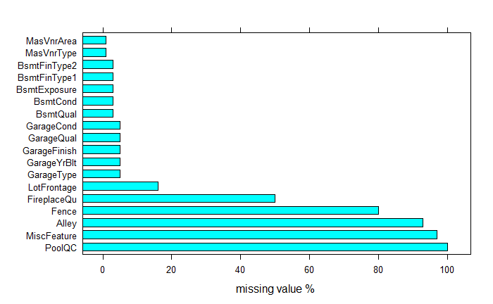

```r
percentage_na<-function(x){
  result<-(round(sum(is.na(x))/length(x),2))*100
  return(result)
}
Variable_na_perc<-sapply(test,percentage_na)
Variable_na_perc<-Variable_na_perc[Variable_na_perc>0]
barchart(sort(Variable_na_perc,decreasing = TRUE),xlab="missing value % ")
```

Plotting the missing value percentage for variables.From the graph above PoolQC, MiscFeature, Alley, Fence and FireplaceQu have more than 50% missing value

```r
#Removing the variables from the dataset which have more than 50% missing values
train_1<-train%>%select(-PoolQC,-MiscFeature,-Alley,-Fence,-FireplaceQu)
#-PoolQC,-MiscFeature,-Alley,-Fence,-FireplaceQu
#Missing value treatment for LotFrontage
#Replacing missing values of lot frontage with median lotfrontage under the neighborhood it falls
lot.by.nbr<-train_1[,c('Neighborhood','LotFrontage')]%>%group_by(Neighborhood)%>%summarise(median=median(LotFrontage,na.rm=TRUE))
idx=which(is.na(train_1$LotFrontage))
for(i in idx){
  lot.median<-lot.by.nbr[lot.by.nbr==as.character(train_1$Neighborhood[i]),'median']
  train_1[i,'LotFrontage']<-lot.median[[1]]
}
#removing rows which have missing value in it
train_treated1<-na.omit(train_1)
```

#### Feature creation

variables like year built,year remodeled and yearGrgbuilt are changed into yrs_old_actual,yrs_old_remodel,yrs_garage_old, reason behind this modification is to change the nature from discrete to continous variables

```r
train_treated1<-train_treated1%>%mutate(yrold.actual=YrSold-YearBuilt,yrold.remodel=YrSold-YearRemodAdd,grg.old=YrSold-GarageYrBlt)
train_treated1<-train_treated1%>%select(-YrSold,-YearBuilt,-YearRemodAdd,-GarageYrBlt)
```

Changing data types from numeric to factor

```r
chng_datatype<-function(x){
  for (i in names(x)){
    if((is.numeric(x[[i]])) & ((length(unique(x[[i]]))/length(x[[i]]))<=0.10)){
      x[[i]]=as.factor(x[[i]])

    }

  }
  return(x)
}
train_treated2<-chng_datatype(train_treated1)
#Changing the variable type manualy
train_treated2$LotFrontage<-as.numeric(levels(train_treated2$LotFrontage)[train_treated2$LotFrontage])
train_treated2$LowQualFinSF<-as.numeric(levels(train_treated2$LowQualFinSF)[train_treated2$LowQualFinSF])
train_treated2$EnclosedPorch<-as.numeric(levels(train_treated2$EnclosedPorch)[train_treated2$EnclosedPorch])
train_treated2$X3SsnPorch<-as.numeric(levels(train_treated2$X3SsnPorch)[train_treated2$X3SsnPorch])
train_treated2$ScreenPorch<-as.numeric(levels(train_treated2$ScreenPorch)[train_treated2$ScreenPorch])
train_treated2$PoolArea<-as.numeric(levels(train_treated2$PoolArea)[train_treated2$PoolArea])
train_treated2$yrold.actual<-as.numeric(levels(train_treated2$yrold.actual)[train_treated2$yrold.actual])
train_treated2$yrold.remodel<-as.numeric(levels(train_treated2$yrold.remodel)[train_treated2$yrold.remodel])
train_treated2$grg.old<-as.numeric(levels(train_treated2$grg.old)[train_treated2$grg.old])
train_treated2$MiscVal<-as.numeric(levels(train_treated2$MiscVal)[train_treated2$MiscVal])
train_treated2$TotRmsAbvGrd<-as.numeric(levels(train_treated2$TotRmsAbvGrd)[train_treated2$TotRmsAbvGrd])
str(train_treated2)
```

```
'data.frame':   1338 obs. of  74 variables:
 $ MSSubClass   : Factor w/ 15 levels "20","30","40",..: 6 1 6 7 6 5 1 6 5 15 ...
 $ MSZoning     : Factor w/ 5 levels "C (all)","FV",..: 4 4 4 4 4 4 4 4 5 4 ...
 $ LotFrontage  : num  65 80 68 60 84 85 75 80 51 50 ...
 $ LotArea      : int  8450 9600 11250 9550 14260 14115 10084 10382 6120 7420 ...
 $ Street       : Factor w/ 2 levels "Grvl","Pave": 2 2 2 2 2 2 2 2 2 2 ...
 $ LotShape     : Factor w/ 4 levels "IR1","IR2","IR3",..: 4 4 1 1 1 1 4 1 4 4 ...
 $ LandContour  : Factor w/ 4 levels "Bnk","HLS","Low",..: 4 4 4 4 4 4 4 4 4 4 ...
 $ Utilities    : Factor w/ 2 levels "AllPub","NoSeWa": 1 1 1 1 1 1 1 1 1 1 ...
 $ LotConfig    : Factor w/ 5 levels "Corner","CulDSac",..: 5 3 5 1 3 5 5 1 5 1 ...
 $ LandSlope    : Factor w/ 3 levels "Gtl","Mod","Sev": 1 1 1 1 1 1 1 1 1 1 ...
 $ Neighborhood : Factor w/ 25 levels "Blmngtn","Blueste",..: 6 25 6 7 14 12 21 17 18 4 ...
 $ Condition1   : Factor w/ 9 levels "Artery","Feedr",..: 3 2 3 3 3 3 3 5 1 1 ...
 $ Condition2   : Factor w/ 8 levels "Artery","Feedr",..: 3 3 3 3 3 3 3 3 3 1 ...
 $ BldgType     : Factor w/ 5 levels "1Fam","2fmCon",..: 1 1 1 1 1 1 1 1 1 2 ...
```

[output cut: 60 more lines]

#### EDA

For continuous variables

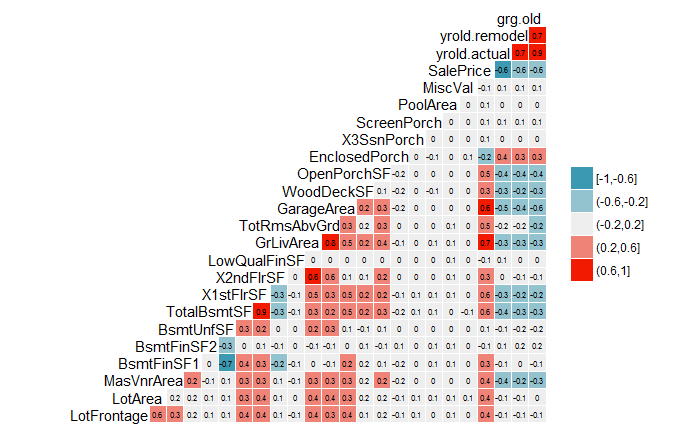

```r
#Taking all the continous variable in a single dataset
train_quant<-train_treated2[sapply(train_treated2,is.numeric)]
#Plotttin correlation between variables
ggcorr(train_quant,method =c("all.obs","spearman"),nbreaks = 5,label=TRUE,label_size = 2,hjust=0.9, layout.exp = 5)
```

From the plot it is clear that multicollinearity is present in the data and Salesprice is highly affected by GrLivArea,GarageArea,LotFrontage,LotArea,MasVnrArea,TotalBsmtSF,X1stFlrSF,yrold.actual,yrold.remodel and grg.old

```r
train_quant_melt<-melt(round(cor(train_quant,method = c('spearman')),2))
train_quant_melt%>%filter(Var2!='SalePrice',Var1!='SalePrice')%>%filter(value>=0.60,value<1)%>%arrange(desc(value))
```

| Var1 | Var2 | value |
| --- | --- | --- |
| grg.old | yrold.actual | 0.89 |
| yrold.actual | grg.old | 0.89 |
| X1stFlrSF | TotalBsmtSF | 0.87 |
| TotalBsmtSF | X1stFlrSF | 0.87 |
| TotRmsAbvGrd | GrLivArea | 0.82 |
| GrLivArea | TotRmsAbvGrd | 0.82 |
| grg.old | yrold.remodel | 0.73 |
| yrold.remodel | grg.old | 0.73 |
| yrold.remodel | yrold.actual | 0.72 |
| yrold.actual | yrold.remodel | 0.72 |

[output cut: 4 more lines]

Table above shows the variables which have high collinearity between themseleves

```r
#Removing the variables which are collinear to each other
train_treated3<-train_treated2%>%select(-X1stFlrSF,-BsmtUnfSF,-X2ndFlrSF,-TotRmsAbvGrd,-yrold.remodel,-grg.old,-LotFrontage)
```

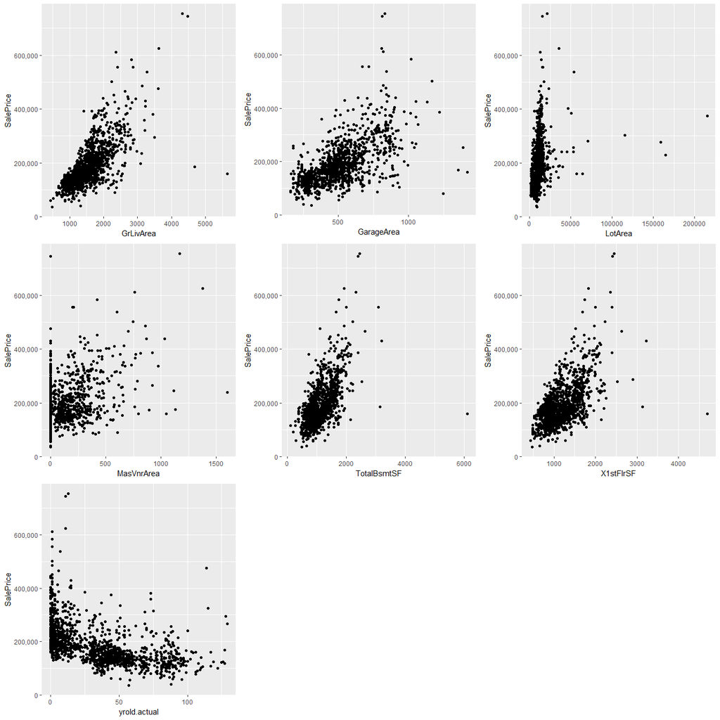

```r
#scatter plot to show the relationship between Salesprice and variables which have high collinearity with SalesPrice
plot1<-qplot(data = train_quant,x=GrLivArea,y=SalePrice)+scale_y_continuous(labels = comma)
plot2<-qplot(data = train_quant,x=GarageArea,y=SalePrice)+scale_y_continuous(labels = comma)
plot3<-qplot(data = train_quant,x=LotArea,y=SalePrice)+scale_y_continuous(labels = comma)
plot4<-qplot(data = train_quant,x=MasVnrArea,y=SalePrice)+scale_y_continuous(labels = comma)
plot5<-qplot(data = train_quant,x=TotalBsmtSF,y=SalePrice)+scale_y_continuous(labels = comma)
plot6<-qplot(data = train_quant,x=X1stFlrSF,y=SalePrice)+scale_y_continuous(labels = comma)
plot7<-qplot(data = train_quant,x=yrold.actual,y=SalePrice)+scale_y_continuous(labels = comma)
grid.arrange(plot1,plot2,plot3,plot4,plot5,plot6,plot7,ncol=3)
```

For categorical variables plotting a boxplot to see the change in mean of salesprice within each category

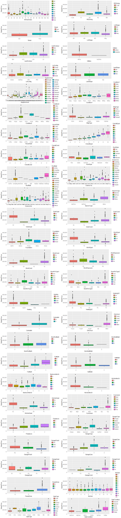

```r
train_qual<-train_treated2[sapply(train_treated2,is.factor)]
train_qual<-cbind(train_qual,train_treated2$SalePrice)
colnames(train_qual)[which(names(train_qual) == "train_treated2$SalePrice")] <- "SalesPrice"
plotdatacolumn<-function(data,column)
  ggplot(data = train_qual,aes(x=data[[column]],y=SalesPrice,fill=data[[column]]))+geom_boxplot()+labs(x=column,fill=column)+scale_y_continuous(labels = comma)
plist<-lapply(colnames(train_qual[,1:ncol(train_qual)-1]),plotdatacolumn,data=train_qual)
do.call("grid.arrange", c(plist, ncol=2))
```

From these boxplots above some categories varies highly with respect to salesprice than others. OverQuall has big impact on sales price whereas the month in which the house was sold does not affect Sales price highly

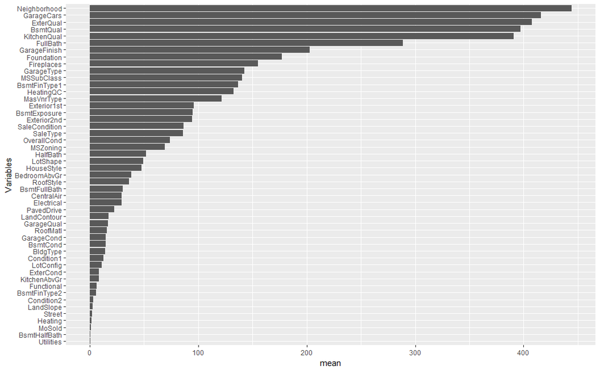

```r
#ANOVA test to check for Salesprice disparity within categorical variables
name<-c()
val<-c()
for(i in names(train_qual[,1:ncol(train_qual)-1])){
  sm<-summary(lm(data = train_qual,SalesPrice~train_qual[[i]]))
  pval<-log(1/pf(sm$fstatistic[1],sm$fstatistic[2],sm$fstatistic[3],lower.tail = FALSE))
  name<-c(name,i)
  val<-c(val,pval)

}
final<-as.data.frame(cbind.data.frame(name,val))
final<-final%>%filter(name!="OverallQual")%>%arrange(desc(val))
ggplot(data = final,aes(x=reorder(name,val),y=val))+geom_bar(stat = "identity")+coord_flip()+labs(y='mean',x='Variables')
```

From the plot above we can observe that some categorcal variables have very high SalePrice disparity as compared to other others.

```r
encode_melt<-melt(round(cor(train_qual_encoded,method=c('spearman')),2))
encode_melt%>%filter(Var2=='SalesPrice')%>%filter(value>=0.50)%>%arrange(desc(value))
```

| Var1 | Var2 | value |
| --- | --- | --- |
| SalesPrice | SalesPrice | 1.00 |
| OverallQual | SalesPrice | 0.80 |
| Neighborhood | SalesPrice | 0.75 |
| ExterQual | SalesPrice | 0.68 |
| BsmtQual | SalesPrice | 0.67 |
| KitchenQual | SalesPrice | 0.67 |
| GarageCars | SalesPrice | 0.67 |
| FullBath | SalesPrice | 0.66 |
| GarageFinish | SalesPrice | 0.59 |
| MSSubClass | SalesPrice | 0.56 |

[output cut: 2 more lines]

So variables like OverallQual,neighborhood,ExterQual,BsmtQual and KitchenQual has high affect on Saleprice.It is quite similar with the ANOVA results we obtained before

```r
#Check For Multicollinearity between categorical variables
encode_melt%>%filter(Var2!='SalesPrice',Var1!='SalesPrice')%>%filter(value>=0.50,value<1)%>%arrange(desc(value))
```

| Var1 | Var2 | value |
| --- | --- | --- |
| Exterior2nd | Exterior1st | 0.93 |
| Exterior1st | Exterior2nd | 0.93 |
| KitchenQual | ExterQual | 0.72 |
| ExterQual | KitchenQual | 0.72 |
| ExterQual | OverallQual | 0.71 |
| OverallQual | ExterQual | 0.71 |
| SaleCondition | SaleType | 0.69 |
| SaleType | SaleCondition | 0.69 |
| BsmtQual | Neighborhood | 0.67 |
| BsmtQual | OverallQual | 0.67 |

[output cut: 88 more lines]

The above table shows the list of variables which have high collinearity between themselves

> So far from the EDA we can conclude that following variables affect SalesPrice
- GrLivArea
- GarageArea
- LotArea
- MasVnrArea
- TotalBsmntSF
- X1stFlrSF
- yrold.actual
- OverallQual
- Neighborhood
- ExterQual

#### Model Building

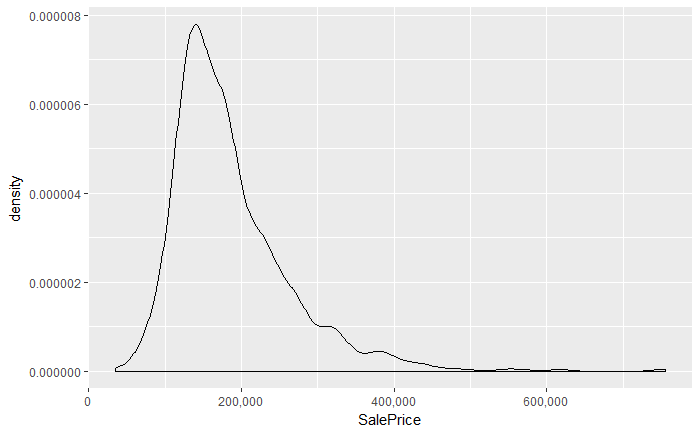

```r
#Check probability density of SalesPrice
ggplot(data = train_treated3,aes(x=SalePrice))+geom_density()+scale_x_continuous(labels = comma)+scale_y_continuous(labels = comma)
```

Sales price is positively skewed as it can be seen from the plot above

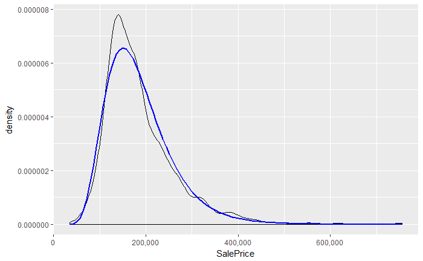

```r
# Checking with Log Normal Distribution
fit<-fitdistr(train_treated3$SalePrice,"lognormal")
ggplot(data = train_treated3,aes(x=SalePrice))+geom_density()+stat_function(fun = dlnorm,args = list(mean=fit$estimate[1],sd=fit$estimate[2]),color="blue",size=1)+scale_y_continuous(labels = comma)+scale_x_continuous(labels = comma)
```

So Lognormal distribution fits SalesPrice very closely

Checking the distribution of other independent variables which are continous in nature

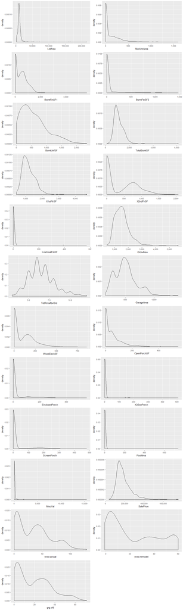

```r
plotdatacolumn<-function(data,column)
ggplot(data=train_quant,aes(x=data[[column]]))+geom_density()+scale_x_continuous(labels=comma)+scale_y_continuous(labels = comma)+labs(x=column)
plist<-lapply(colnames(train_quant[,-1]),plotdatacolumn,data=train_quant)
do.call("grid.arrange", c(plist, ncol=2))
```

From these distributions plot above we can observe that most of the distribution has posistive skewness and doing a lognoraml transformation will be ideal fit

#### Transforming variables

```r
train_treated3$SalePrice=log1p(train_treated3$SalePrice)
train_treated3$LotArea=log1p(train_treated3$LotArea)
train_treated3$GrLivArea=log1p(train_treated3$GrLivArea)
train_treated3$GarageArea=log1p(train_treated3$GarageArea)
```

#### OLS Model

```r
set.seed(1)
train_control<-trainControl(method = 'cv',number = 10) #K-Fold cross validation
model<-train(SalePrice~GrLivArea+GarageArea+LotArea+MasVnrArea+TotalBsmtSF+yrold.actual+Neighborhood+ExterQual,data=train_treated3,trControl=train_control,method='lm')
model
```

[output not shown]

```r
summary(model)
```

[output not shown]

#### Ridge Regression

```r
#Ridge Regression
x<-model.matrix(SalePrice~.,data = train_treated3)[,-1] #creating a matrix of predictor variables
y<-train_treated3$SalePrice # Vector of target variable
grid<-seq(1,0,-0.001)
ctrl<-trainControl(method = 'repeatedcv',number = 10,repeats = 5)
set.seed(100)
ridge.mod<-train(x,y,method = 'glmnet',tuneGrid = expand.grid(alpha=0,lambda=grid),metric = 'RMSE',maximize = FALSE,trControl = ctrl)
```

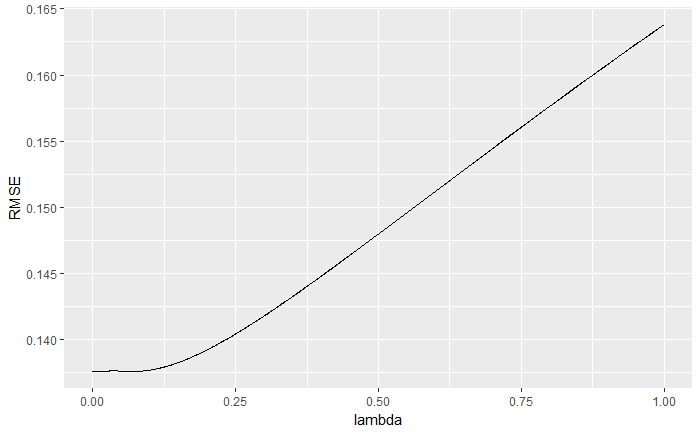

```r
#Plotting alpha vs RMSE
ggplot(data=filter(ridge.mod$result))+geom_line(aes(x=lambda,y=RMSE))
```

```r
mean(ridge.mod$resample$RMSE)
```

```
[1] 0.1376076
```

```r
#LASSO Model
set.seed(121)
lasso.mod<-train(x,y,method = 'glmnet',tuneGrid = expand.grid(alpha=1,lambda=grid),metric = 'RMSE',maximize = FALSE,trControl = ctrl)
```

```
There were missing values in resampled performance measures.
```

```r
lasso.mod
```

```
glmnet

1338 samples
 275 predictor

No pre-processing
Resampling: Cross-Validated (10 fold, repeated 5 times)
Summary of sample sizes: 1205, 1204, 1204, 1205, 1204, 1203, ...
Resampling results across tuning parameters:

  lambda  RMSE       Rsquared
  0.000   0.1541477  0.8372585
  0.001   0.1368585  0.8675165
  0.002   0.1325384  0.8749894
  0.003   0.1320249  0.8759909
  0.004   0.1320383  0.8762054
  0.005   0.1325383  0.8756316
  0.006   0.1333954  0.8745271
  0.007   0.1345693  0.8729198
  0.008   0.1359717  0.8709108
  0.009   0.1375596  0.8685430
  0.010   0.1392156  0.8660243
  0.011   0.1407894  0.8636611
  0.012   0.1422439  0.8615333
  0.013   0.1435974  0.8595882
  0.014   0.1449090  0.8576904
  0.015   0.1461632  0.8558662
  0.016   0.1474112  0.8540256
  0.017   0.1486877  0.8521053
  0.018   0.1499609  0.8501849
  0.019   0.1512510  0.8482114
  0.020   0.1525626  0.8461790
  0.021   0.1538865  0.8441129
  0.022   0.1552516  0.8419397
  0.023   0.1565880  0.8398049
  0.024   0.1579574  0.8375695
  0.025   0.1592885  0.8354084
  0.026   0.1606160  0.8332414
  0.027   0.1619795  0.8309623
  0.028   0.1633242  0.8287203
```

[output cut: 294 more lines]

```
  0.323   0.3760249        NaN
  0.324   0.3760249        NaN
  0.325   0.3760249        NaN
  0.326   0.3760249        NaN
  0.327   0.3760249        NaN
  0.328   0.3760249        NaN
  0.329   0.3760249        NaN
  0.330   0.3760249        NaN
  0.331   0.3760249        NaN
  0.332   0.3760249        NaN
 [ reached getOption("max.print") -- omitted 668 rows ]

Tuning parameter 'alpha' was held constant at a value of 1
RMSE was used to select the optimal model using  the smallest value.
The final values used for the model were alpha = 1 and lambda = 0.003.
```

```r
mean(lasso.mod$resample$RMSE)
```

```
[1] 0.1320249
```

```r
#Extracticting the important coefficients from LASSO model
coef<-data.frame(coef.name=dimnames(coef(lasso.mod$finalModel,s=lasso.mod$bestTune$lambda))[[1]],coef.value=matrix(coef(lasso.mod$finalModel,s=lasso.mod$bestTune$lambda)))
#exclude the intercept term
coef<-coef[-1,]
```

#### extract the top 10 and bottom 10 features from the LASSO model

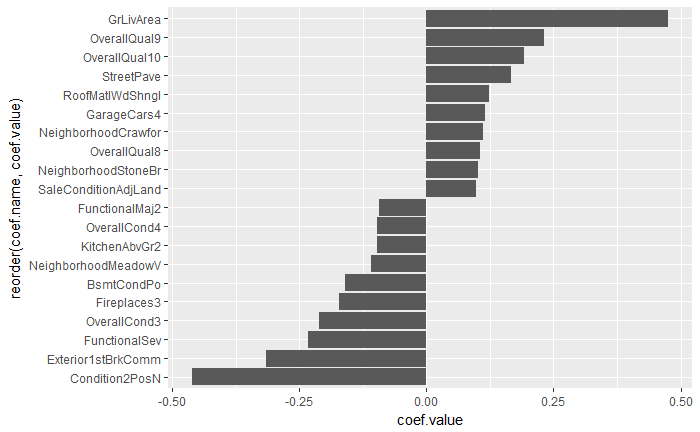

```r
#extract the top 10 and bottom 10 features
coef<-arrange(coef,-coef.value)
imp_coef<-rbind(head(coef,10),tail(coef,10))
ggplot(imp_coef) +geom_bar(aes(x=reorder(coef.name,coef.value),y=coef.value),stat="identity")+coord_flip()
```